## BRC Census

# Life in BRC

## Leave No Trace and On-Playa Power

## Leave No Trace

# Participant Indications of Waste Sorting at Camp in BRC*

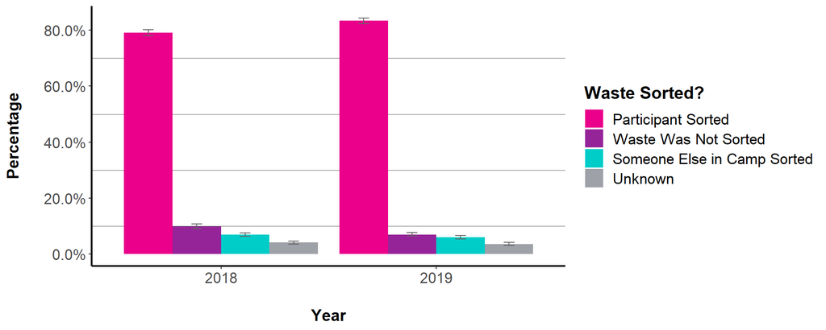

Error bars indicate the upper and lower bounds of the 95% confidence intervals.

|  | 2018 Percent | 2018 MoE +/- % |  | 2019 Percent | 2019 MoE +/- % |
| --- | --- | --- | --- | --- | --- |
| Participant Sorted | 79.1 | 1.2 |  | 83.4 | 1.0 |
| Waste Was Not Sorted | 9.9 | 0.8 |  | 7.0 | 0.6 |
| Someone Else in Camp Sorted | 6.9 | 0.6 |  | 6.0 | 0.6 |
| Unknown | 4.1 | 0.6 |  | 3.6 | 0.6 |

*The 2016 and 2017 online surveys included differently worded questions about trash sorting, so direct comparison is impossible. In 2016 and 2017 respectively, 75.0% (+/- 1.2) and 78.1% (+/- 1.2) of participants reported sorting waste at their own camp, 6.6% (+/- 0.8) and 5.4% (+/- 0.8) of participants reported that someone else in their camp sorted waste, and 3.4% (+/- 0.6) and 2.4% (+/- 0.4) did not know.*

## Leave No Trace

# Types of Waste Sorted at Camp in BRC*

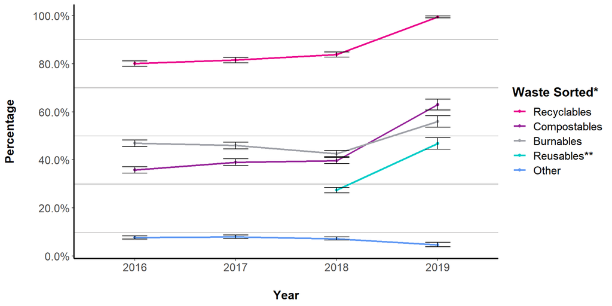

Error bars indicate the upper and lower bounds of the 95% confidence intervals.

|  | 2016 Percent | 2016 MoE +/- % |  | 2017 Percent | 2017 MoE +/- % |  | 2018 Percent | 2018 MoE +/- % |  | 2019 Percent | 2019 MoE +/- % |
| --- | --- | --- | --- | --- | --- | --- | --- | --- | --- | --- | --- |
| Recyclables | 80.1 | 1.2 |  | 81.5 | 1.2 |  | 83.8 | 1.0 |  | 99.5 | 0.4 |
| Compostables | 35.8 | 1.4 |  | 39.0 | 1.4 |  | 39.7 | 1.2 |  | 63.0 | 2.4 |
| Burnables | 46.9 | 1.4 |  | 46.0 | 1.4 |  | 42.6 | 1.2 |  | 56.0 | 2.4 |
| Reusables** | NA | NA |  | NA | NA |  | 27.4 | 1.2 |  | 46.8 | 2.4 |
| Other | 7.7 | 0.8 |  | 8.0 | 0.8 |  | 7.2 | 0.6 |  | 4.6 | 1.0 |

## Leave No Trace

# Post-Event Trash Disposal Strategies*

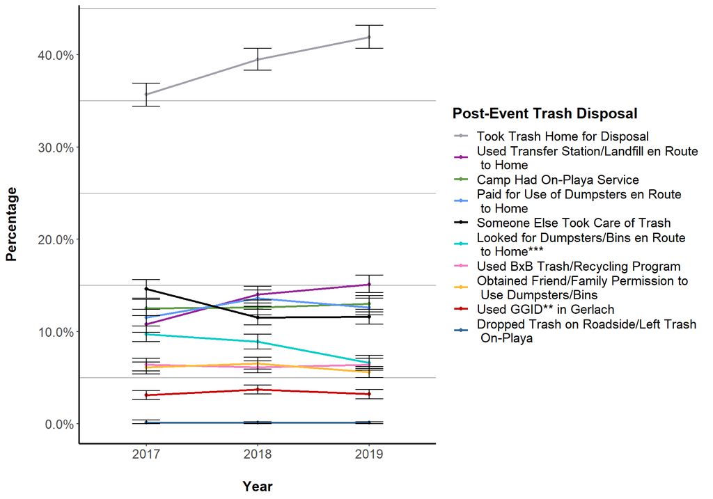

Error bars indicate the upper and lower bounds of the 95% confidence intervals.

|  | 2017 Percent | 2017 MoE +/- % |  | 2018 Percent | 2018 MoE +/- % |  | 2019 Percent | 2019 MoE +/- % |
| --- | --- | --- | --- | --- | --- | --- | --- | --- |
| Took Trash Home for Disposal | 35.7 | 1.2 |  | 39.5 | 1.2 |  | 41.9 | 1.4 |
| Used Transfer Station/Landfill en Route to Home | 10.8 | 0.8 |  | 14.0 | 1.0 |  | 15.1 | 1.0 |
| Camp Had On-Playa Service | 12.5 | 1.0 |  | 12.6 | 0.8 |  | 13.0 | 0.8 |
| Paid for Use of Dumpsters en Route to Home | 11.5 | 0.8 |  | 13.6 | 1.0 |  | 12.6 | 1.0 |
| Someone Else Took Care of Trash | 14.6 | 1.0 |  | 11.5 | 0.8 |  | 11.6 | 0.8 |
| Looked for Dumpsters/Bins en Route to Home*** | 9.7 | 0.8 |  | 8.9 | 0.8 |  | 6.6 | 0.8 |
| Used BxB Trash/Recycling Program | 6.4 | 0.8 |  | 6.1 | 0.6 |  | 6.4 | 0.6 |
| Obtained Friend/Family Permission to Use Dumpsters/Bins | 6.1 | 0.6 |  | 6.5 | 0.6 |  | 5.6 | 0.6 |
| Used GGID** in Gerlach | 3.1 | 0.6 |  | 3.7 | 0.6 |  | 3.2 | 0.6 |
| Dropped Trash on Roadside/Left Trash On-Playa | 0.1 | 0.2 |  | 0.1 | 0.0 |  | 0.1 | 0.0 |

## On-Playa Power

# Power Source(s) Used On-Playa*

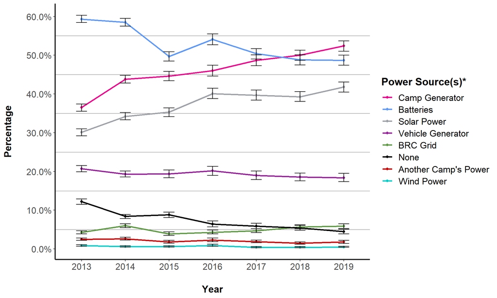

Error bars indicate the upper and lower bounds of the 95% confidence intervals.

* Participants selected all option(s) that applied.

|  | 2013 Percent | 2013 MoE +/- % |  | 2014 Percent | 2014 MoE +/- % |  | 2015 Percent | 2015 MoE +/- % |  | 2016 Percent | 2016 MoE +/- % |  | 2017 Percent | 2017 MoE +/- % |  | 2018 Percent | 2018 MoE +/- % |  | 2019 Percent | 2019 MoE +/- % |
| --- | --- | --- | --- | --- | --- | --- | --- | --- | --- | --- | --- | --- | --- | --- | --- | --- | --- | --- | --- | --- |
| Camp Generator | 36.5 | 1.0 |  | 43.8 | 1.0 |  | 44.6 | 1.2 |  | 46.0 | 1.4 |  | 48.7 | 1.4 |  | 50.0 | 1.4 |  | 52.4 | 1.4 |
| Batteries | 59.3 | 1.0 |  | 58.5 | 1.0 |  | 49.7 | 1.2 |  | 54.1 | 1.4 |  | 50.4 | 1.4 |  | 48.8 | 1.4 |  | 48.7 | 1.4 |
| Solar Power | 30.1 | 1.0 |  | 34.2 | 1.0 |  | 35.3 | 1.2 |  | 40.1 | 1.4 |  | 39.7 | 1.4 |  | 39.3 | 1.2 |  | 41.8 | 1.4 |
| Vehicle Generator | 20.7 | 0.8 |  | 19.3 | 0.8 |  | 19.4 | 1.0 |  | 20.2 | 1.2 |  | 19.0 | 1.2 |  | 18.6 | 1.0 |  | 18.4 | 1.0 |
| BRC Grid | 4.3 | 0.4 |  | 6.0 | 0.6 |  | 3.9 | 0.4 |  | 4.3 | 0.6 |  | 4.7 | 0.6 |  | 5.7 | 0.6 |  | 5.9 | 0.6 |
| None | 12.2 | 0.6 |  | 8.4 | 0.6 |  | 8.8 | 0.8 |  | 6.4 | 0.8 |  | 5.9 | 0.8 |  | 5.4 | 0.6 |  | 4.5 | 0.6 |
| Another Camp’s Power | 2.5 | 0.4 |  | 2.6 | 0.4 |  | 1.8 | 0.4 |  | 2.3 | 0.4 |  | 1.9 | 0.4 |  | 1.5 | 0.4 |  | 1.8 | 0.4 |
| Wind Power | 0.9 | 0.2 |  | 0.6 | 0.2 |  | 0.6 | 0.2 |  | 0.9 | 0.2 |  | 0.4 | 0.2 |  | 0.4 | 0.2 |  | 0.5 | 0.2 |

## On-Playa Power

# Vehicle Generator Fuel Type*

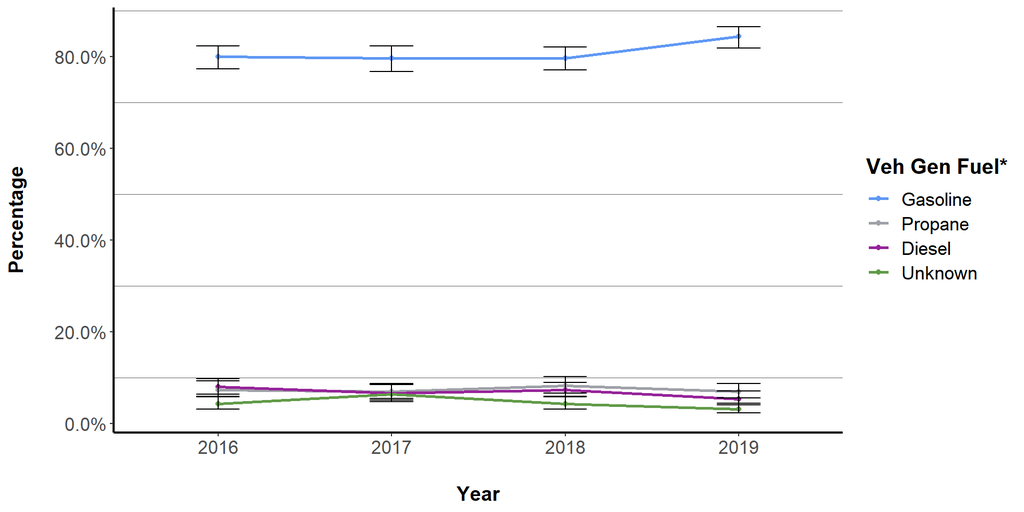

Error bars indicate the upper and lower bounds of the 95% confidence intervals.

* Data presented in the plot above and table below represent participants who indicated use of a vehicle generator for on-playa power.

|  | 2016 Percent | 2016 MoE +/- % |  | 2017 Percent | 2017 MoE +/- % |  | 2018 Percent | 2018 MoE +/- % |  | 2019 Percent | 2019 MoE +/- % |
| --- | --- | --- | --- | --- | --- | --- | --- | --- | --- | --- | --- |
| Gasoline | 80.0 | 2.5 |  | 79.7 | 2.7 |  | 79.7 | 2.5 |  | 84.4 | 2.4 |
| Propane | 7.4 | 1.8 |  | 7.0 | 1.6 |  | 8.3 | 1.8 |  | 7.0 | 1.6 |
| Diesel | 8.0 | 1.8 |  | 6.6 | 1.8 |  | 7.4 | 1.6 |  | 5.4 | 1.6 |
| Unknown | 4.3 | 1.4 |  | 6.4 | 1.8 |  | 4.3 | 1.2 |  | 3.2 | 1.0 |

*In the 2016, 2017, 2018, and 2019 online surveys respectively, these participants reported an average of 3.0 (+/- 0.2), 3.9 (+/- 0.3), 3.3 (+/- 0.2), 4.0 (+/- 0.3) hours of vehicle generator use per day.*

## On-Playa Power

# Camp Generator Fuel Type*

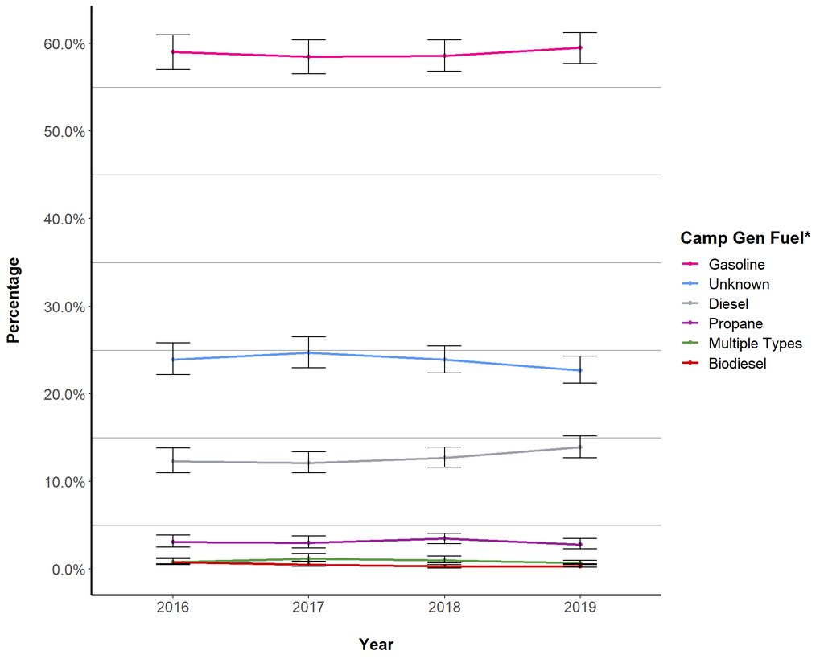

Error bars indicate the upper and lower bounds of the 95% confidence intervals.

* Data presented in the plot above and table below represent participants who indicated use of a camp generator for on-playa power.

|  | 2016 Percent | 2016 MoE +/- % |  | 2017 Percent | 2017 MoE +/- % |  | 2018 Percent | 2018 MoE +/- % |  | 2019 Percent | 2019 MoE +/- % |
| --- | --- | --- | --- | --- | --- | --- | --- | --- | --- | --- | --- |
| Gasoline | 59.0 | 2.0 |  | 58.5 | 2.0 |  | 58.6 | 1.8 |  | 59.5 | 1.8 |
| Unknown | 23.9 | 1.8 |  | 24.7 | 1.8 |  | 23.9 | 1.6 |  | 22.7 | 1.6 |
| Diesel | 12.3 | 1.4 |  | 12.1 | 1.2 |  | 12.7 | 1.2 |  | 13.9 | 1.2 |
| Propane | 3.1 | 0.8 |  | 3.0 | 0.6 |  | 3.5 | 0.6 |  | 2.8 | 0.6 |
| Multiple Types | 0.8 | 0.4 |  | 1.2 | 0.4 |  | 1.0 | 0.4 |  | 0.7 | 0.2 |
| Biodiesel | 0.8 | 0.4 |  | 0.5 | 0.2 |  | 0.3 | 0.2 |  | 0.3 | 0.2 |

*In the 2016, 2017, 2018, and 2019 online surveys respectively, these participants reported an average of 10.5, 11.4, 11.0, and 11.8 (all +/- 0.4) hours of camp generator use per day.*

## On-Playa Power

# Camp Generator Output*

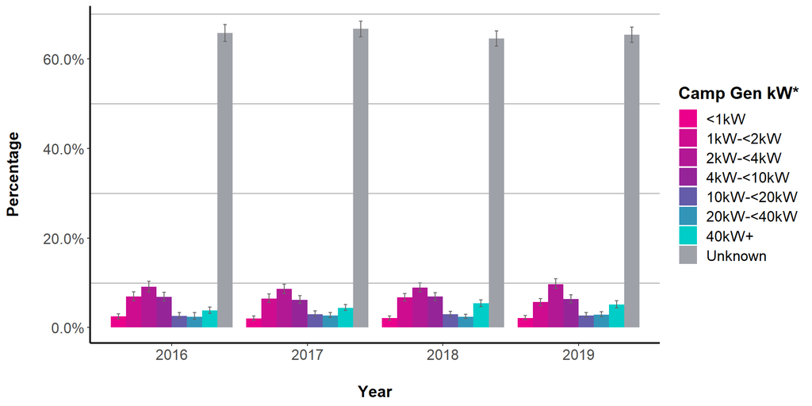

Error bars indicate the upper and lower bounds of the 95% confidence intervals.

* Data presented in the plot above and table below represent participants who indicated use of a camp generator for on-playa power.

|  | 2016 Percent | 2016 MoE +/- % |  | 2017 Percent | 2017 MoE +/- % |  | 2018 Percent | 2018 MoE +/- % |  | 2019 Percent | 2019 MoE +/- % |
| --- | --- | --- | --- | --- | --- | --- | --- | --- | --- | --- | --- |
| <1kW | 2.5 | 0.6 |  | 2.0 | 0.6 |  | 2.1 | 0.4 |  | 2.1 | 0.6 |
| 1kW-<2kW | 6.9 | 1.0 |  | 6.5 | 1.0 |  | 6.7 | 1.0 |  | 5.7 | 0.8 |
| 2kW-<4kW | 9.1 | 1.2 |  | 8.6 | 1.0 |  | 8.9 | 1.0 |  | 9.7 | 1.2 |
| 4kW-<10kW | 6.8 | 1.0 |  | 6.2 | 0.8 |  | 6.9 | 1.0 |  | 6.4 | 0.8 |
| 10kW-<20kW | 2.6 | 0.6 |  | 3.0 | 0.6 |  | 3.0 | 0.6 |  | 2.7 | 0.6 |
| 20kW-<40kW | 2.4 | 0.8 |  | 2.7 | 0.6 |  | 2.4 | 0.6 |  | 2.9 | 0.6 |
| 40kW+ | 3.8 | 0.6 |  | 4.4 | 0.6 |  | 5.4 | 0.8 |  | 5.1 | 0.8 |
| Unknown | 65.8 | 2.0 |  | 66.7 | 1.8 |  | 64.6 | 1.8 |  | 65.4 | 1.8 |

**Next:** Event Logistics: Ticket Source, Participant Expenses, Impacts on Nevada State, and Other Recreation